# Zadanie 4

Kacper Szmigielski

2026-02-03

# Zadanie 4

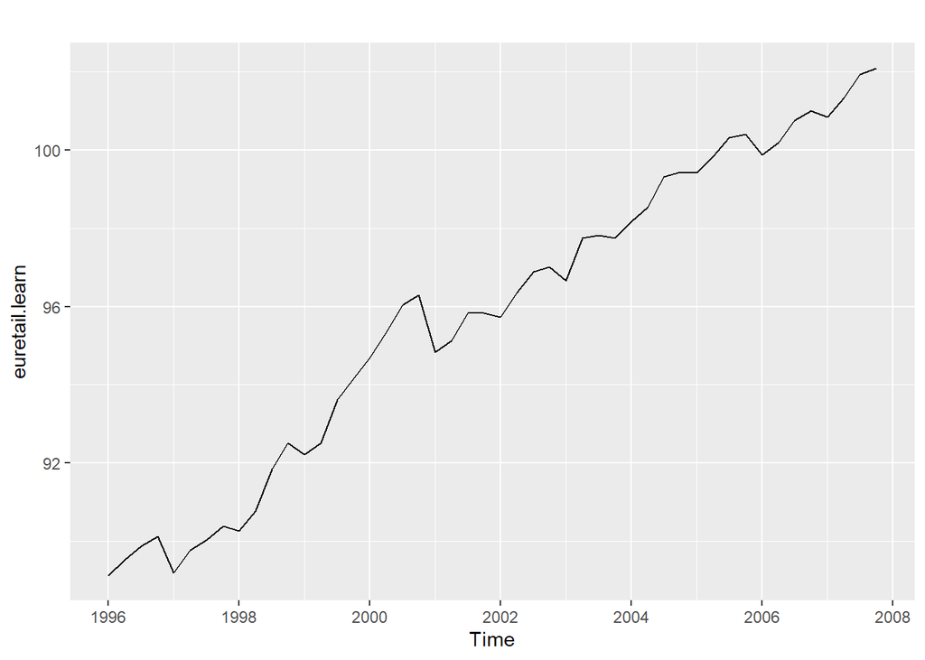

Wykres autoplot nie sugeruje znacznych wzrostów wariancji szeregu czasowego wraz z upływem czasu.

[output not shown]

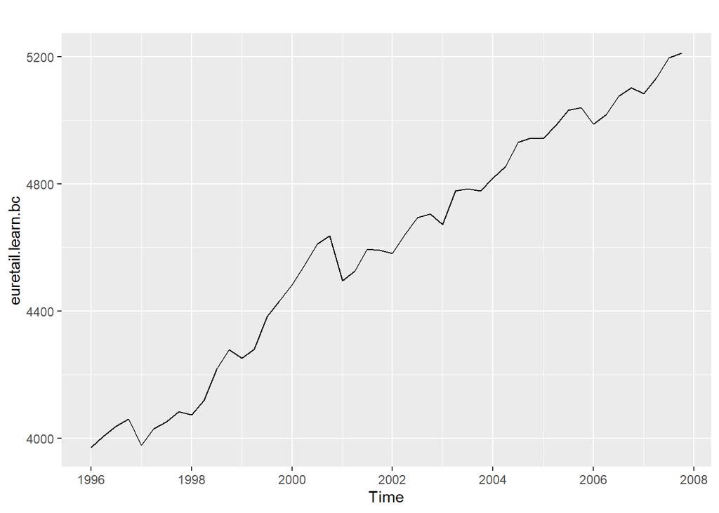

Dane po tranformacji boxa-coxa

Teraz sprawdzamy sugerowane wartości różnicowań

Funkcja ndiffs proponuje 1 różnicowań z opóźnieniem 1.

Natomiast funkcja **nsdiffs** proponuje 1 różnicowań z opóźnieniem sezonowym 4

Wykonujemy proponowane różnicowania na danych

```r
euretail.learn.4 <- diff(euretail.learn, lag=4)
euretail.learn.4.1 <- diff(euretail.learn.4, lag=1)
```

Po zróżnicowaniu nasz szereg ma postać:

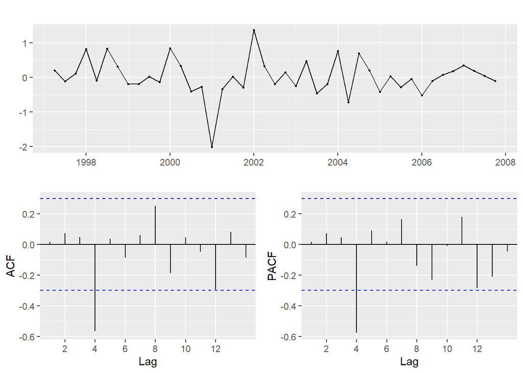

Wykres danych euretail po zastosowaniu transformacji

# - - - - - - - - - - - - - - - - - - - - - - - - - - - - - - - - - - - - - - -

# Identyfikacja modeli AR(p) oraz MA(q) oraz ARIMA

# - - - - - - - - - - - - - - - - - - - - - - - - - - - - - - - - - - - - - - -

# wykresy ACF, PACF danych uczących po transformacjach

# za pomocą ggtsdisplay

ggtsdisplay(euretail.learn.4.1.1)

### Czy średnia jest równa 0? (–> ważne dla uwzględnienia dryfu w modelu ARIMA)

mean(euretail.learn.4.1.1) # 0.0072

### modele na bazie PACF oraz ACF to odpowiednio AR(4) oraz MA(9)

### oznaczane jako

### [model.ar] oraz [model.ma]

model.ar <- Arima(euretail.learn, order=c(4,2,0), seasonal=c(0,1,0))

model.ma <- Arima(euretail.learn, order=c(0,2,9), seasonal=c(0,1,0))

#________________________________________________________________ # UWAGA 1: # W przypadku modeli ARIMA ewentualnie można zastanowiać się też # nad AR(1), MA(5), MA(4) albo MA(1) # (ale nie umiszczać ich w sprawozdaniu, jeśli nie wnoszą # nic ciekawego) #________________________________________________________________

#_________________________________________________________________ # UWAGA 2: # Skoro średnia = 0.0072 , to warto sprawdzić też modele # z dryfem dodając argument “include.drift = TRUE” w funkcji Arima # Zobacz Przykład 3: Dopasowanie modelu ARIMA # dla szeregu gnp (R skrypt) #_________________________________________________________________

# model automatyczny ARIMA

# oznaczane jako

# [model.auto] - ustawiamy dodatkowo stepwise=FALSE, approximation=FALSE

# aby dokładniej przeszukować potencjalne modele, zgodnie z uwagą

# w dokumentacji funkcji auto.arima():

# ”

# If you are analysing just one time series, and can afford to take some

# more time, it is recommended that you set

# stepwise=FALSE and approximation=FALSE.

# ”

model.auto <- auto.arima(euretail.learn, stepwise=FALSE, approximation=FALSE) # ARIMA(0,1,3)(0,1,1)[4]

#_______________________________________________________________________ # UWAGA 3: # Warto sprawdzić modele automatyczne optymalizujące “aicc” albo “bic”. # Zobacz Przykład 2: dopasowanie modelu ARIMA z uwzględnieniem oceny # istotności współczynników (R skrypt) #_______________________________________________________________________

#___________________________________________________________________________ # UWAGA 4: # Warto sprawdzić istotność wspołczynników otrzymanych modeli. # Czy zostawienie tylko współczynników istotnych poprawia jakość dopasowania # modelu? # Zobacz Przykład 2: dopasowanie modelu ARIMA z uwzględnieniem oceny # istotności współczynników (R skrypt) #___________________________________________________________________________

# - - - - - - - - - - - - - - - - - - - - - - - - - - - - - - - - - - - - - - -

# Identyfikacja modeli dekompozycji tslm()

# - - - - - - - - - - - - - - - - - - - - - - - - - - - - - - - - - - - - - - -

# [model.tslm.0] oraz [model.tslm.1] oraz [model.tslm.2]

model.tslm.0 <- tslm(euretail.learn ~ trend) model.tslm.1 <- tslm(euretail.learn ~ season + trend) model.tslm.2 <- tslm(euretail.learn ~ season + trend + I(trend^2))

# - - - - - - - - - - - - - - - - - - - - - - - - - - - - - - - - - - - - - - -

# Identyfikacja modeli algorytmów wygładzania wykładniczego (modele ETS)

# - - - - - - - - - - - - - - - - - - - - - - - - - - - - - - - - - - - - - - -

# proste wygładzanie wykładnicze (algorytm SES) oznaczane jako [model.ses]

model.ses <- ses(euretail.learn, h=h, initial=“simple”)

# modele z algorytmu Holta oznaczane jako [model.holt] oraz [model.holt.damped]

model.holt <- holt(euretail.learn, h=h) model.holt.damped <- holt(euretail.learn, h=h, damped=TRUE)

# modele z algorytmu Holta-Wintersa oznaczane jako [model.hw.add] oraz [model.hw.mult]

model.hw.add <- hw(euretail.learn, seasonal=“additive”) model.hw.mult <- hw(euretail.learn, seasonal=“multiplicative”)

# model ETS (automatyczny za pomocą ets()) oznaczany jako [model.ets]

model.ets <- ets(euretail.learn) model.ets1 <- ets(euretail.learn, model=“MAM”) # niekoniecznie sensowny wybór

#___________________________________________________________________________ # UWAGA 6: # Zainteresowani mogą sprawdzić też inne modele ses tj. z # np. initial=“optimal” lub innymi zmienionymi parametrami, # ale w samym sprawozdaniu wystarczy zasadniczo jeden ses # (ten, który uważamy za najlepszy) #___________________________________________________________________________

#___________________________________________________________________________ # UWAGA 7: # wystarczy model.ets, ale jeśli jesteśmy w stanie podać lepszy model ets # np. ustawiając odpowiednio parametry, to można to pokazać w sprawozdaniu # ale nie jest to jednak konieczne. #___________________________________________________________________________

#_______________________________________________________________________________ # #————— 3 - Wyznaczenie prognoz dla zbioru testowego —————— #_______________________________________________________________________________ # Wyznaczenie prognoz dla zbioru testowego na podstawie dopasowanych modeli # oraz wybranej metody referencyjnej (tzn. wybranej naiwnej metody # prognozowania). ( # # Wskazówka: można zastosować funkcje meanf(), naive(), snaive() lub rwf() # z pakietu forecast. # - - - - - - - - - - - - - - - - - - - - - - - - - - - - - - - - - - - - - - -

# 1. prognozy dla modeli arima

# 1.1 ar

# 1.2 ma

# 1.3 auto

# 2. prognozy dla modeli dekompozycji

# 2.1 tslm0

# 2.2 tslm1

# 3. prognozy dla modeli ets

# 3.1 ses

# 3.2 holt + holt damped

# 3.3 hw-add + hw-mult

# 3.4 ets

# 4 metody referencyjne

# 4.1 prognoza oparta na średniej

# 4.2 standardowa metoda naiwna

# 4.3 sezonowa metoda naiwna

# 4.4 metoda uwzględniająca dryf

# Wskazówka:

# Zobacz plik

# Przyklad1_prognozowanie_szeregow_czasowych.R

# do listy 2

# 1.1

forecast.model.ar <- forecast::forecast(model.ar, h=h) # 1.2 forecast.model.ma <- forecast::forecast(model.ma, h=h)

# 1.3

forecast.model.auto <- forecast::forecast(model.auto, h=h)

# 2.1

forecast.model.tslm0 <- forecast::forecast(model.tslm.0, h=h) # 2.2 forecast.model.tslm1 <- forecast::forecast(model.tslm.1, h=h) # 2.3 forecast.model.tslm2 <- forecast::forecast(model.tslm.2, h=h)

# 3.1

forecast.model.ses <- forecast::forecast(model.ses, h=h) # 3.2 forecast.model.holt <- forecast::forecast(model.holt, h=h) forecast.model.holt.damped <- forecast::forecast(model.holt.damped, h=h) # 3.3 forecast.model.hw.add <- forecast::forecast(model.hw.add, h=h) forecast.model.hw.mult <- forecast::forecast(model.hw.mult, h=h) # 3.4 forecast.model.ets <- forecast::forecast(model.ets, h=h) forecast.model.ets.1 <- forecast::forecast(model.ets1, h=h)

# 4.1

forecast.mean <- meanf(x=euretail.learn, h=8) # 4.2 forecast.naive <- naive(x=euretail.learn, h=8) # 4.3 forecast.snaive <- snaive(x=euretail.learn, h=8) # 4.4 forecast.rwf <- rwf(x=euretail.learn, h=8, drift=TRUE)

#_______________________________________________________________________________ # #————- 4 - Przedstawienie skonstruowanych prognoz na wykresie———– #_______________________________________________________________________________ # Przedstawienie skonstruowanych prognoz na wykresie # i porównanie z wartościami rzeczywistymi (zbiór testowy). # - - - - - - - - - - - - - - - - - - - - - - - - - - - - - - - - - - - - - - -

# 1.1

autoplot(forecast.model.ar) + autolayer(euretail.test) # 1.2 autoplot(forecast.model.ma) + autolayer(euretail.test) # 1.3 autoplot(forecast.model.auto) + autolayer(euretail.test)

# 2.1

autoplot(forecast.model.tslm0) + autolayer(euretail.test) # 2.2 autoplot(forecast.model.tslm1) + autolayer(euretail.test) # 2.3 autoplot(forecast.model.tslm2) + autolayer(euretail.test)

# 3.1

autoplot(forecast.model.ses) + autolayer(euretail.test) # 3.2 autoplot(forecast.model.holt) + autolayer(euretail.test) autoplot(forecast.model.holt.damped) + autolayer(euretail.test) # 3.3 autoplot(forecast.model.hw.add) + autolayer(euretail.test) autoplot(forecast.model.hw.mult) + autolayer(euretail.test) # 3.4 autoplot(forecast.model.ets) + autolayer(euretail.test) autoplot(forecast.model.ets.1) + autolayer(euretail.test)

# 4.1

autoplot(forecast.mean) + autolayer(euretail.test) # 4.2 autoplot(forecast.naive) + autolayer(euretail.test) # 4.3 autoplot(forecast.snaive) + autolayer(euretail.test) # 4.4 autoplot(forecast.rwf) + autolayer(euretail.test)

#_______________________________________________________________________________ # #———————- 5 - Porównanie dokładności prognoz ————– #_______________________________________________________________________________ # Porównanie dokładności prognoz dla zbioru testowego i uczącego # z uwzględnieniem wybranych miar oceny dokładności, np. RMSE, MAE, MAPE i MASE. # # Wskazówka: można wykorzystać funkcję accuracy() z pakietu forecast. # - - - - - - - - - - - - - - - - - - - - - - - - - - - - - - - - - - - - - - -#

# 1.1

accuracy(forecast.model.ar, euretail.test) # 1.2 accuracy(forecast.model.ma, euretail.test) # 1.3 accuracy(forecast.model.auto, euretail.test)

# 2.1

accuracy(forecast.model.tslm0, euretail.test) # 2.2 accuracy(forecast.model.tslm1, euretail.test) # 2.3 accuracy(forecast.model.tslm2, euretail.test)

# 3.1

accuracy(forecast.model.ses, euretail.test) # 3.2 accuracy(forecast.model.holt, euretail.test) accuracy(forecast.model.holt.damped, euretail.test) # 3.3 accuracy(forecast.model.hw.add, euretail.test) accuracy(forecast.model.hw.mult, euretail.test) # 3.4 accuracy(forecast.model.ets, euretail.test) accuracy(forecast.model.ets.1, euretail.test)

# 4.1

accuracy(forecast.mean, euretail.test) # 4.2 accuracy(forecast.naive, euretail.test) # 4.3 accuracy(forecast.snaive, euretail.test) # 4.4 accuracy(forecast.rwf, euretail.test)

#_______________________________________________________________________________ # #———– 6 - Wnioski dotyczące wyboru optymalnego modelu —————— #_______________________________________________________________________________ # Wnioski dotyczące wyboru optymalnego modelu. # Które podejście do modelowania wydaje się bardziej adekwatne # dla rozważanego szeregu czasowego? # - - - - - - - - - - - - - - - - - - - - - - - - - - - - - - - - - - - - - - -#

# Do samodzielnego wykonania.